# Mammal data - Arid Desert

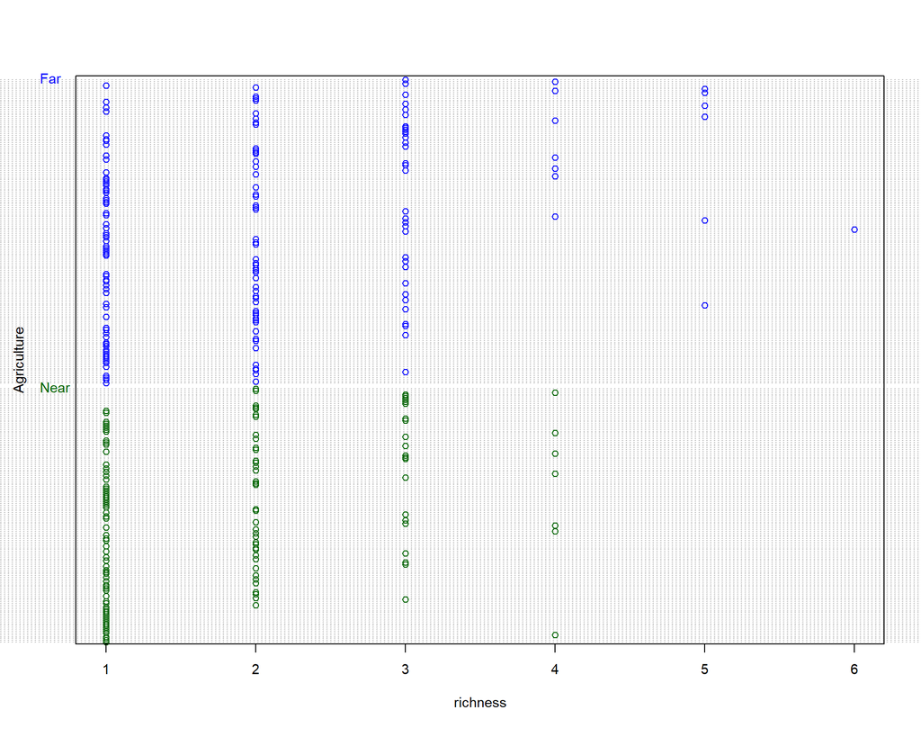

```r
my_cols <- c("blue", "darkgreen")
dotchart(P.anal$richness, ylab = "Agriculture",
         groups = P.anal$Agriculture, gcolor = my_cols,
         color = my_cols[P.anal$Agriculture],
         cex = 0.9,  pch = 1, xlab = "richness")
```

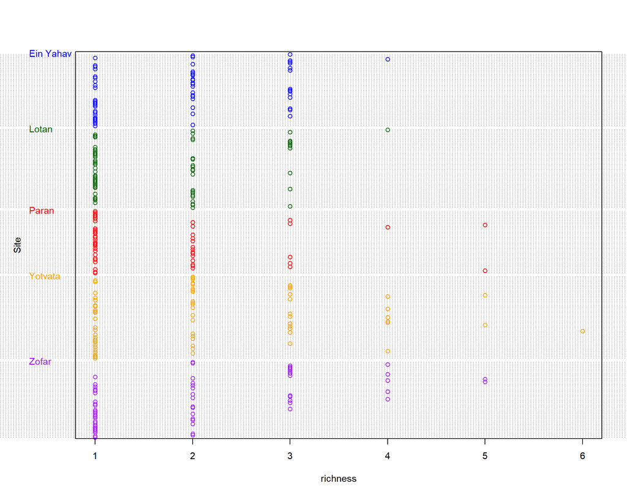

```r
my_cols <- c("blue", "darkgreen", "red", "orange", "purple")
dotchart(P.anal$richness, ylab = "Site",
         groups = P.anal$Site, gcolor = my_cols,
         color = my_cols[P.anal$Site],
         cex = 0.9,  pch = 1, xlab = "richness")
```

```r
kable(summary(P.anal[,.(richness, abundance, rescaled_Time.Diff, cosinus_Monitoring.Time.Diff, sinus_Monitoring.Time.Diff, Site, Transect, Transect_with_date, Distance_agri_rescaled)]))
```

|  | richness | abundance | rescaled_Time.Diff | cosinus_Monitoring.Time.Diff | sinus_Monitoring.Time.Diff | Site | Transect | Transect_with_date | Distance_agri_rescaled |
| --- | --- | --- | --- | --- | --- | --- | --- | --- | --- |
|  | Min. :1.000 | Min. : 1.00 | Min. :-1.2473 | Min. :-0.9844 | Min. :-0.9538 | Ein Yahav:59 | Lotan Far : 38 | Ein Yahav Far_16_07_2022 : 9 | Min. :-0.68190 |
|  | 1st Qu.:1.000 | 1st Qu.: 2.00 | 1st Qu.:-0.4567 | 1st Qu.:-0.1804 | 1st Qu.:-0.4121 | Lotan :64 | Yotvata Near : 34 | Ein Yahav Near_16_07_2022: 9 | 1st Qu.:-0.47903 |
|  | Median :2.000 | Median : 5.00 | Median : 0.1395 | Median : 0.3755 | Median :-0.1324 | Paran :51 | Zofar Far : 34 | Lotan Far_24_08_2022 : 9 | Median : 0.03654 |
|  | Mean :1.884 | Mean : 10.02 | Mean : 0.2774 | Mean : 0.2386 | Mean : 0.1085 | Yotvata :67 | Yotvata Far : 33 | Paran Near_16_11_2016 : 9 | Mean : 0.19731 |
|  | 3rd Qu.:2.000 | 3rd Qu.: 11.00 | 3rd Qu.: 1.3302 | 3rd Qu.: 0.8532 | 3rd Qu.: 0.9200 | Zofar :62 | Ein Yahav Far: 31 | Yotvata Far_06_10_2018 : 9 | 3rd Qu.: 0.79490 |
|  | Max. :6.000 | Max. :118.00 | Max. : 1.3751 | Max. : 0.9912 | Max. : 0.9995 | NA | Paran Far : 29 | Yotvata Near_06_09_2022 : 9 | Max. : 2.37740 |
|  | NA | NA | NA | NA | NA | NA | (Other) :104 | (Other) :249 | NA |

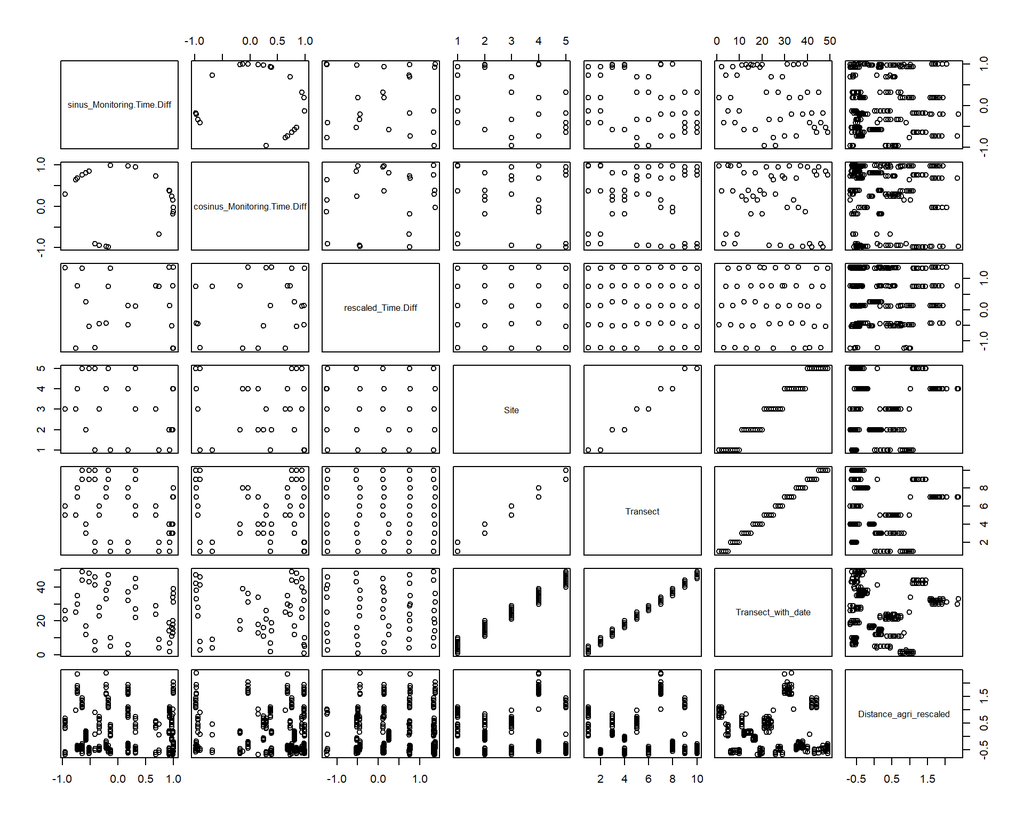

```r
pairs(P.anal[,lapply(X = .SD,FUN = as.numeric),.SDcols=c("sinus_Monitoring.Time.Diff", "cosinus_Monitoring.Time.Diff", "rescaled_Time.Diff","Site","Transect", "Transect_with_date", "Distance_agri_rescaled")])
```

```r
kable(cor(P.anal[,lapply(X = .SD,FUN = as.numeric),.SDcols=c("sinus_Monitoring.Time.Diff", "cosinus_Monitoring.Time.Diff", "rescaled_Time.Diff","Site","Transect", "Transect_with_date", "Distance_agri_rescaled")]))
```

|  | sinus_Monitoring.Time.Diff | cosinus_Monitoring.Time.Diff | rescaled_Time.Diff | Site | Transect | Transect_with_date | Distance_agri_rescaled |
| --- | --- | --- | --- | --- | --- | --- | --- |
| sinus_Monitoring.Time.Diff | 1.0000000 | -0.0086829 | -0.0362440 | -0.3317552 | -0.3358655 | -0.3280949 | 0.0415841 |
| cosinus_Monitoring.Time.Diff | -0.0086829 | 1.0000000 | 0.2815373 | -0.1389841 | -0.1416740 | -0.1498081 | -0.0534359 |
| rescaled_Time.Diff | -0.0362440 | 0.2815373 | 1.0000000 | 0.0201873 | 0.0375285 | 0.0539297 | -0.0584075 |
| Site | -0.3317552 | -0.1389841 | 0.0201873 | 1.0000000 | 0.9851579 | 0.9795745 | 0.0882773 |
| Transect | -0.3358655 | -0.1416740 | 0.0375285 | 0.9851579 | 1.0000000 | 0.9950592 | -0.0436044 |
| Transect_with_date | -0.3280949 | -0.1498081 | 0.0539297 | 0.9795745 | 0.9950592 | 1.0000000 | -0.0566318 |
| Distance_agri_rescaled | 0.0415841 | -0.0534359 | -0.0584075 | 0.0882773 | -0.0436044 | -0.0566318 | 1.0000000 |

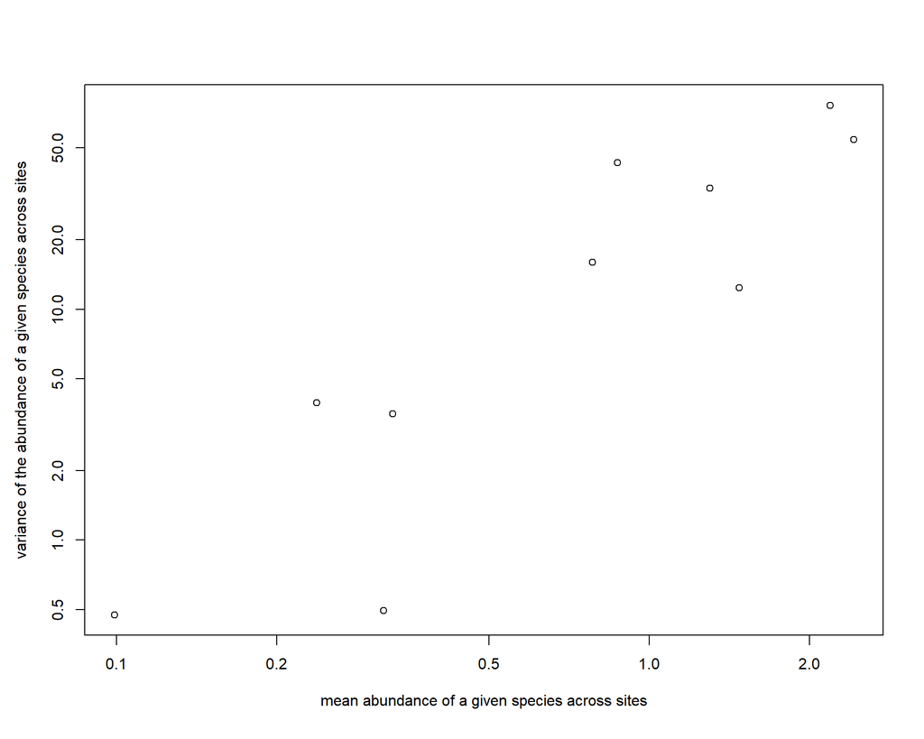

```r
meanvar.plot(spp, xlab = "mean abundance of a given species across sites", ylab = "variance of the abundance of a given species across sites")
```

```r
mdl_r.poiss.int <- glm(data = P.anal, formula = richness ~ Distance_agri_rescaled * rescaled_Time.Diff + cosinus_Monitoring.Time.Diff + sinus_Monitoring.Time.Diff + Site + Transect_with_date, family = poisson)
od <- mdl_r.poiss.int$deviance/mdl_r.poiss.int$df.residual
print("Estimating overdispersion parameter phi: (Res. Dev.)/(n-p) where n=number of observations; p=number of parameters in the model.")
```

```
## [1] "Estimating overdispersion parameter phi: (Res. Dev.)/(n-p) where n=number of observations; p=number of parameters in the model."
```

```r
print(paste0('od = ',od))
```

```
## [1] "od = 0.324325977068647"
```

Overdispersion parameter is <1 (underdispersion) and therefore will use Poisson

```r
m0 <- glm(data = P.anal, formula =  richness ~ Distance_agri_rescaled * rescaled_Time.Diff + cosinus_Monitoring.Time.Diff + sinus_Monitoring.Time.Diff, family = poisson)

me0transectwithdate <- glmer(data = P.anal, formula =   richness ~ Distance_agri_rescaled * rescaled_Time.Diff + cosinus_Monitoring.Time.Diff + sinus_Monitoring.Time.Diff +  (1|Transect_with_date), family = poisson, verbose = 1)
```

[output not shown]

```
## boundary (singular) fit: see help('isSingular')
```

```r
me0transect <- glmer(data = P.anal, formula =   richness ~ Distance_agri_rescaled * rescaled_Time.Diff + cosinus_Monitoring.Time.Diff + sinus_Monitoring.Time.Diff +  (1|Transect), family = poisson, verbose = 1)
```

[output not shown]

```
## boundary (singular) fit: see help('isSingular')
```

```r
me0site <- glmer(data = P.anal, formula =   richness ~ Distance_agri_rescaled * rescaled_Time.Diff + cosinus_Monitoring.Time.Diff + sinus_Monitoring.Time.Diff +  (1|Site), family = poisson, verbose = 1)
```

[output not shown]

```
## boundary (singular) fit: see help('isSingular')
```

All GLMERs result in singular fit, will use regular GLM:

```r
m1 <- step(m0)
```

```
## Start:  AIC=883.07
## richness ~ Distance_agri_rescaled * rescaled_Time.Diff + cosinus_Monitoring.Time.Diff +
##     sinus_Monitoring.Time.Diff
##
##                                             Df Deviance    AIC
## - Distance_agri_rescaled:rescaled_Time.Diff  1   128.69 881.13
## - sinus_Monitoring.Time.Diff                 1   128.78 881.22
## - cosinus_Monitoring.Time.Diff               1   129.26 881.70
## <none>                                           128.62 883.07
##
## Step:  AIC=881.13
## richness ~ Distance_agri_rescaled + rescaled_Time.Diff + cosinus_Monitoring.Time.Diff +
##     sinus_Monitoring.Time.Diff
##
##                                Df Deviance    AIC
## - sinus_Monitoring.Time.Diff    1   128.82 879.26
## - cosinus_Monitoring.Time.Diff  1   129.35 879.79
## <none>                              128.69 881.13
## - Distance_agri_rescaled        1   138.09 888.53
## - rescaled_Time.Diff            1   140.82 891.26
##
## Step:  AIC=879.26
## richness ~ Distance_agri_rescaled + rescaled_Time.Diff + cosinus_Monitoring.Time.Diff
##
##                                Df Deviance    AIC
## - cosinus_Monitoring.Time.Diff  1   129.51 877.95
## <none>                              128.82 879.26
## - Distance_agri_rescaled        1   138.19 886.64
## - rescaled_Time.Diff            1   141.14 889.58
##
## Step:  AIC=877.95
## richness ~ Distance_agri_rescaled + rescaled_Time.Diff
##
##                          Df Deviance    AIC
## <none>                        129.51 877.95
## - Distance_agri_rescaled  1   138.64 885.08
## - rescaled_Time.Diff      1   144.35 890.80
```

Final model includes distance from agriculture and time difference

```r
summ(m1, exp = TRUE, digits=3)
```

| Observations | 303 |
| --- | --- |
| Dependent variable | richness |
| Type | Generalized linear model |
| Family | poisson |
| Link | log |

| χ²(2) | 22.896 |
| --- | --- |
| Pseudo-R² (Cragg-Uhler) | 0.077 |
| Pseudo-R² (McFadden) | 0.026 |
| AIC | 877.952 |
| BIC | 889.093 |

|  | exp(Est.) | 2.5% | 97.5% | z val. | p |
| --- | --- | --- | --- | --- | --- |
| (Intercept) | 1.699 | 1.543 | 1.871 | 10.796 | 0.000 |
| Distance_agri_rescaled | 1.171 | 1.059 | 1.296 | 3.065 | 0.002 |
| rescaled_Time.Diff | 1.207 | 1.096 | 1.330 | 3.813 | 0.000 |

Standard errors: MLE

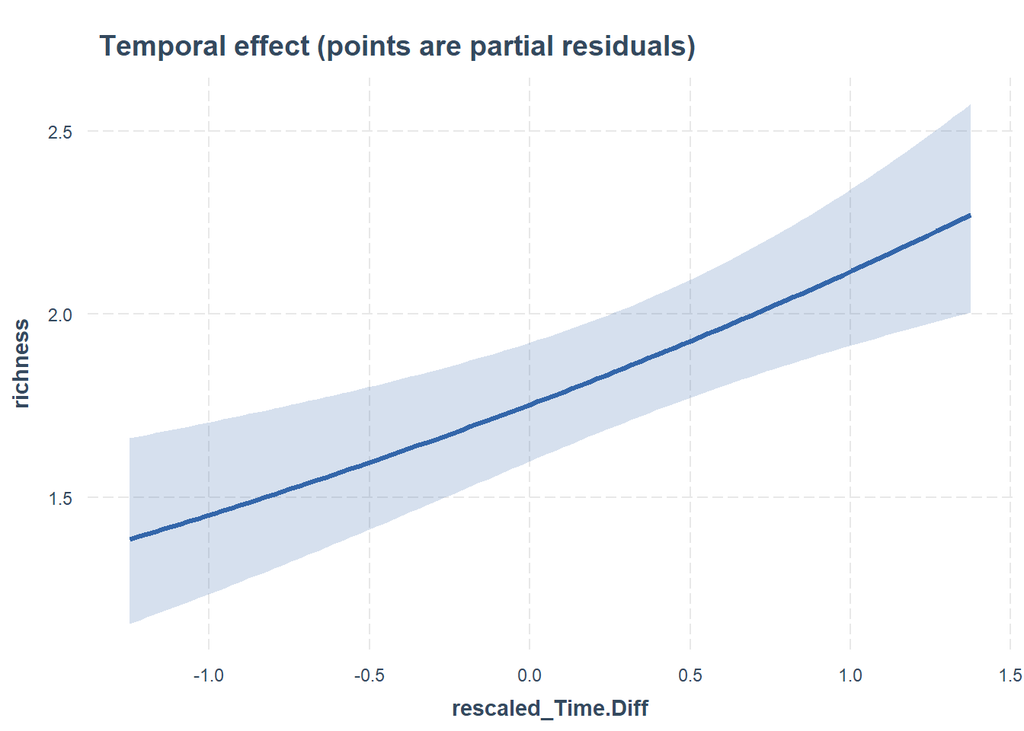

```r
effect_plot(model = m1, data=P.anal, pred = rescaled_Time.Diff, interval = T, plot.points = F, jitter = c(0.1,0), point.size = 3, cat.pred.point.size = 4, partial.residuals = F, colors = "Qual1", main.title = "Temporal effect (points are partial residuals)")
```

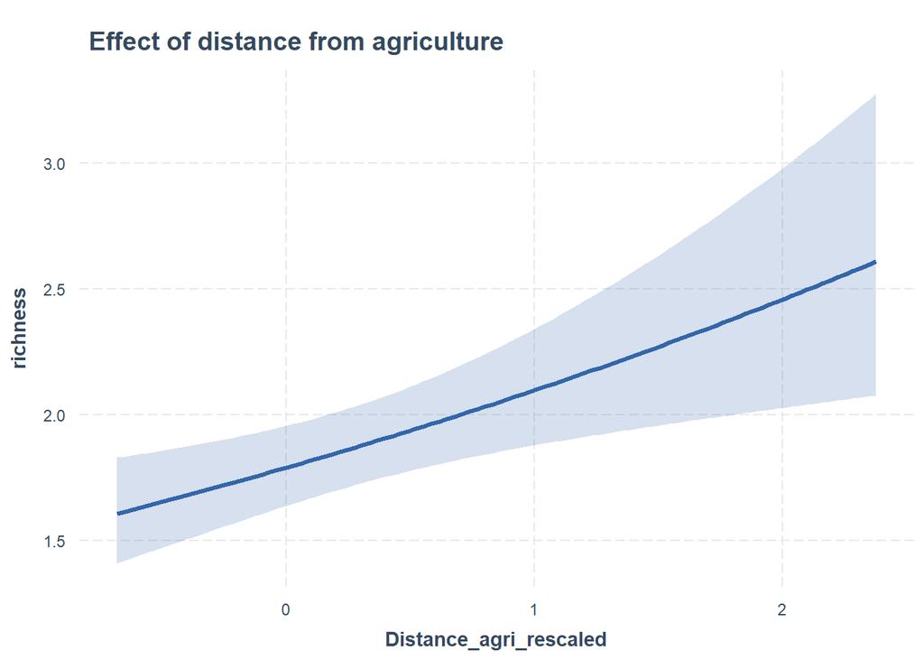

```r
effect_plot(model = m1, data=P.anal, pred = Distance_agri_rescaled, interval = T, plot.points = F, jitter = c(0.1,0), point.size = 3, cat.pred.point.size = 4, partial.residuals = F, colors = "Qual1", main.title = "Effect of distance from agriculture")
```

Time difference and distance from agriculture significantly affect species richness

#### community analysis using package MVabund

Table of abundances per species by camera ID

```r
abundance_and_cameras <- as.data.table(abu_by_spp.AridDesert[,c(5,27:40)])
dim(abundance_and_cameras)
```

```
## [1] 303  15
```

```r
canisau <- abundance_and_cameras[,2] > 0
sum(canisau)
```

```
## [1] 37
```

```r
canislup <- abundance_and_cameras[,3] > 0
sum(canislup)
```

```
## [1] 52
```

```r
capra <- abundance_and_cameras[,4] > 0
sum(capra)
```

```
## [1] 37
```

```r
Doma <- abundance_and_cameras[,5] > 0
sum(Doma)
```

```
## [1] 0
```

```r
Equus <- abundance_and_cameras[,6] > 0
sum(Equus)
```

```
## [1] 18
```

```r
Gazellador <- abundance_and_cameras[,7] > 0
sum(Gazellador)
```

```
## [1] 106
```

```r
Gazellagaz <- abundance_and_cameras[,8] > 0
sum(Gazellagaz)
```

```
## [1] 0
```

```r
Hyaena <- abundance_and_cameras[,9] > 0
sum(Hyaena)
```

```
## [1] 69
```

```r
Hystrix <- abundance_and_cameras[,10] > 0
sum(Hystrix)
```

```
## [1] 10
```

```r
Lepus <- abundance_and_cameras[,11] > 0
sum(Lepus)
```

```
## [1] 109
```

```r
Meles <- abundance_and_cameras[,12] > 0
sum(Meles)
```

```
## [1] 0
```

```r
Oryx <- abundance_and_cameras[,13] > 0
sum(Oryx)
```

```
## [1] 8
```

```r
Sus <- abundance_and_cameras[,14] > 0
sum(Sus)
```

```
## [1] 0
```

```r
Vulpus <- abundance_and_cameras[,15] > 0
sum(Vulpus)
```

```
## [1] 125
```

303 cameras total. Species with a minimum of 20 cameras - Canis aureus, Canis lupus, Capra nubiana, Gazella dorcas, Hyaena hyaena, Lepus capensis and vulpus vulpus

```r
spp_no_rare <- abu_by_spp.AridDesert[,27:40]
print(colSums(spp_no_rare))
```

```
##      Canis aureus       Canis lupus     Capra nubiana Dama mesopotamica
##               264               237               394                 0
##    Equus hemionus    Gazella dorcas   Gazella gazella     Hyaena hyaena
##               100               733                 0                96
##    Hystrix indica    Lepus capensis       Meles meles     Oryx leucoryx
##                30               662                 0                72
##        Sus scrofa     Vulpes vulpes
##                 0               447
```

```r
# filter out species with less than 20 individuals (rare species)
spp_no_rare <- spp_no_rare[,.SD,.SDcols = colSums(spp_no_rare)>20]
spp_no_rare <- mvabund(spp_no_rare[,c(-4,-7,-9)])
print(colSums(spp_no_rare))
```

```
##   Canis.aureus    Canis.lupus  Capra.nubiana Gazella.dorcas  Hyaena.hyaena
##            264            237            394            733             96
## Lepus.capensis  Vulpes.vulpes
##            662            447
```

Left with 7 species

```r
env_data <- abu_by_spp.AridDesert[,..col_names]
env_data$Site <- factor(env_data$Site, levels=c("Yotvata","Lotan","Paran", "Zofar", "Ein Yahav"))

mva_m0.po <- manyglm(formula = spp_no_rare ~ Distance_agri_rescaled * rescaled_Time.Diff + cosinus_Monitoring.Time.Diff + sinus_Monitoring.Time.Diff, family = "poisson", data = env_data)

mva_m0.nb <- manyglm(formula = spp_no_rare ~ Distance_agri_rescaled * rescaled_Time.Diff + cosinus_Monitoring.Time.Diff + sinus_Monitoring.Time.Diff, family = "negative.binomial", data = env_data)

aic_dt <- data.table(nb = mva_m0.nb$aic, po=mva_m0.po$aic)
colMeans(aic_dt)
```

```
##       nb       po
##  630.101 1517.274
```

```r
print("POISSON")
```

```
## [1] "POISSON"
```

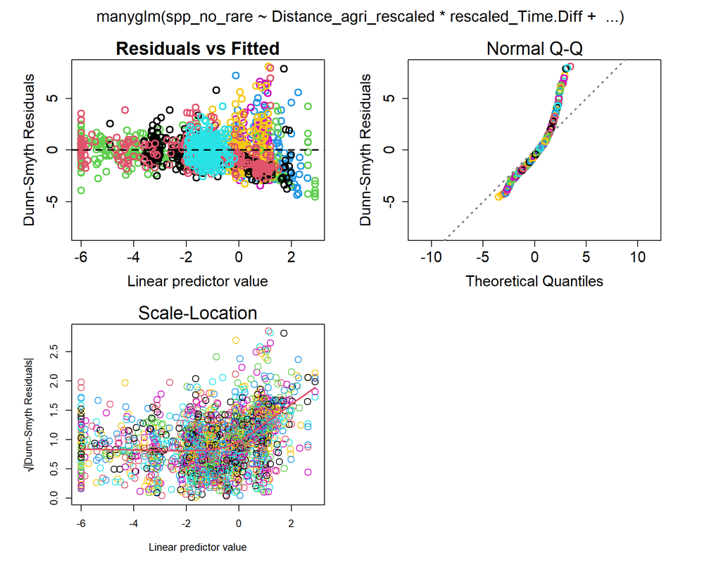

```r
plot(mva_m0.po, which=1:3)
```

```r
print("NEGATIVE BINOMIAL")
```

```
## [1] "NEGATIVE BINOMIAL"
```

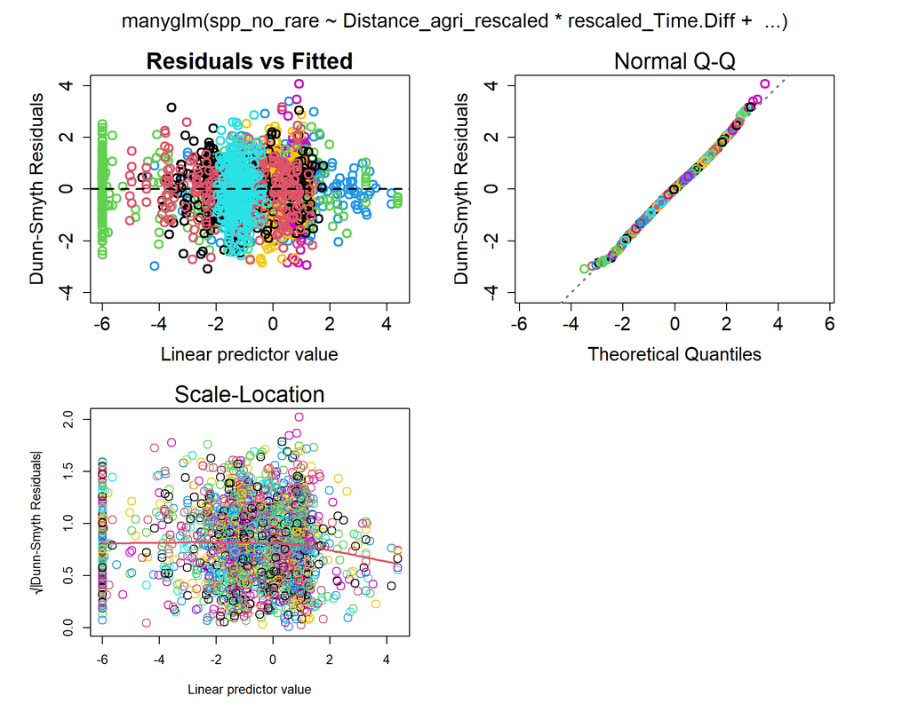

```r
plot(mva_m0.nb, which=1:3)
```

prefer negative binomial because standardized residuals are smaller.

```r
# mva_m0 <- mva_m0.po
# mva_m1 <- manyglm(formula = spp_no_rare ~ Distance_agri_rescaled * rescaled_Time.Diff + dunes*rescaled_Time.Diff + Distance_agri_rescaled:dunes + cos_td_rad + sin_td_rad + site, family = "poisson", data = env_data)
# aic_dt$po1 <- mva_m1$aic
mva_m0 <- mva_m0.nb
mva_m1 <- manyglm(formula = spp_no_rare ~ Distance_agri_rescaled * rescaled_Time.Diff + cosinus_Monitoring.Time.Diff + sinus_Monitoring.Time.Diff + Transect_with_date, data = env_data)
aic_dt$nb1 <- mva_m1$aic
colMeans(aic_dt)
```

```
##        nb        po       nb1
##  630.1010 1517.2736  577.3289
```

```r
mva_m2 <- manyglm(formula = spp_no_rare ~ Distance_agri_rescaled * rescaled_Time.Diff + cosinus_Monitoring.Time.Diff + sinus_Monitoring.Time.Diff + Transect, data = env_data)
aic_dt$nb2 <- mva_m2$aic
colMeans(aic_dt)
```

```
##        nb        po       nb1       nb2
##  630.1010 1517.2736  577.3289  575.0241
```

```r
mva_m3 <- manyglm(formula = spp_no_rare ~ Distance_agri_rescaled * rescaled_Time.Diff + cosinus_Monitoring.Time.Diff + sinus_Monitoring.Time.Diff + Site, data = env_data)
aic_dt$nb3 <- mva_m2$aic
colMeans(aic_dt)
```

```
##        nb        po       nb1       nb2       nb3
##  630.1010 1517.2736  577.3289  575.0241  575.0241
```

## Many GLM with Site:

```r
mva_m0.nb <- manyglm(formula = spp_no_rare ~ Distance_agri_rescaled * rescaled_Time.Diff + cosinus_Monitoring.Time.Diff + sinus_Monitoring.Time.Diff + Site, family = "negative.binomial", data = env_data)
drop1(mva_m0.nb)
```

```
## Single term deletions
##
## Model:
## spp_no_rare ~ Distance_agri_rescaled * rescaled_Time.Diff + cosinus_Monitoring.Time.Diff +
##     sinus_Monitoring.Time.Diff + Site
##                                           Df    AIC
## <none>                                       4130.7
## cosinus_Monitoring.Time.Diff               7 4160.9
## sinus_Monitoring.Time.Diff                 7 4168.7
## Site                                      28 4410.7
## Distance_agri_rescaled:rescaled_Time.Diff  7 4141.8
```

Final model includes all factors.

```r
# mva_m2 <- manyglm(formula = spp_no_rare ~ Distance_agri_rescaled + dunes*rescaled_Time.Diff + Distance_agri_rescaled:dunes + cos_td_rad + sin_td_rad, family = "poisson", data = env_data)
# mva_m2 <- manyglm(formula = spp_no_rare ~ Distance_agri_rescaled * rescaled_Time.Diff + cosinus_Monitoring.Time.Diff + Site, family = "negative.binomial", data = env_data)
# drop1(mva_m2)
```

```r
# mva_m2 <- manyglm(formula = spp_no_rare ~ Distance_agri_rescaled + dunes + rescaled_Time.Diff + Distance_agri_rescaled:dunes + cos_td_rad + sin_td_rad, family = "poisson", data = env_data)
# mva_m2 <- manyglm(formula = spp_no_rare ~ Distance_agri_rescaled * rescaled_Time.Diff + Site, family = "negative.binomial", data = env_data)
# drop1(mva_m2)
```

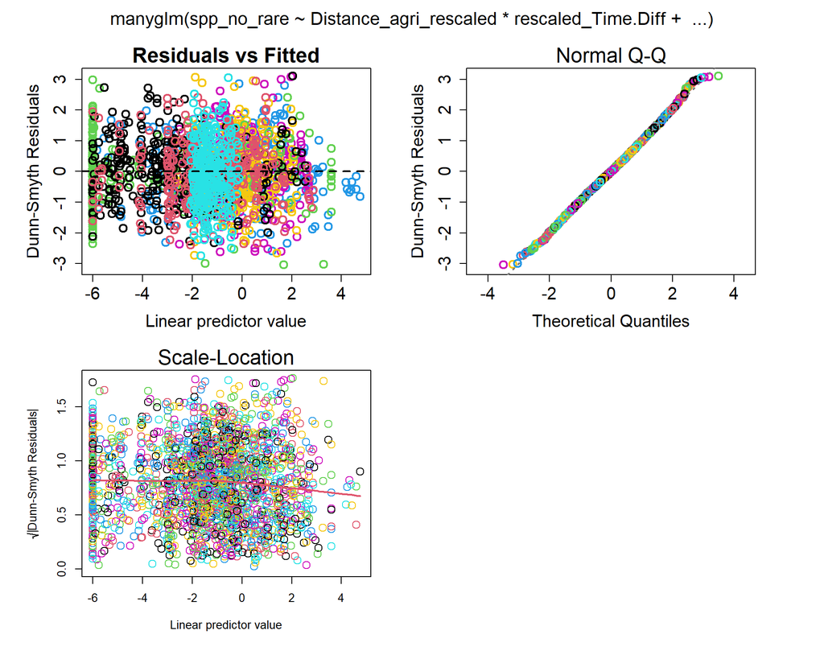

```r
plot(mva_m0.nb, which=1:3)
```

```r
#summ_m2 <- summary(mva_m0.nb)
#saveRDS(summ_m2, "output/summ_model_arid_site.RDS")
summ_m2 <- readRDS("../output/summ_model_arid_site.RDS")
#anov_m2.uni <- anova(mva_m0.nb, p.uni = "adjusted")
#saveRDS(anov_m2.uni, "output/anova_arid_site.RDS")
anov_m2.uni <- readRDS("../output/anova_arid_site.RDS")
print(summ_m2)
```

```
##
## Test statistics:
##                                           wald value Pr(>wald)
## (Intercept)                                   13.525     0.001 ***
## Distance_agri_rescaled                        13.810     0.001 ***
## rescaled_Time.Diff                             8.096     0.001 ***
## cosinus_Monitoring.Time.Diff                   6.887     0.001 ***
## sinus_Monitoring.Time.Diff                     6.383     0.001 ***
## SiteLotan                                     10.473     0.001 ***
## SiteParan                                      9.145     0.001 ***
## SiteZofar                                     13.015     0.001 ***
## SiteEin Yahav                                 12.449     0.001 ***
## Distance_agri_rescaled:rescaled_Time.Diff      5.569     0.001 ***
## ---
## Signif. codes:  0 '***' 0.001 '**' 0.01 '*' 0.05 '.' 0.1 ' ' 1
##
## Test statistic:  24.74, p-value: 0.001
## Arguments:
##  Test statistics calculated assuming response assumed to be uncorrelated
##  P-value calculated using 999 resampling iterations via pit.trap resampling (to account for correlation in testing).
```

```r
print(anov_m2.uni)
```

```
## Analysis of Deviance Table
##
## Model: spp_no_rare ~ Distance_agri_rescaled * rescaled_Time.Diff + cosinus_Monitoring.Time.Diff + sinus_Monitoring.Time.Diff + Site
##
## Multivariate test:
##                                           Res.Df Df.diff   Dev Pr(>Dev)
## (Intercept)                                  302
## Distance_agri_rescaled                       301       1  82.2    0.001 ***
## rescaled_Time.Diff                           300       1  77.9    0.002 **
## cosinus_Monitoring.Time.Diff                 299       1  30.0    0.003 **
## sinus_Monitoring.Time.Diff                   298       1  94.2    0.001 ***
## Site                                         294       4 332.2    0.001 ***
## Distance_agri_rescaled:rescaled_Time.Diff    293       1  25.1    0.004 **
## ---
## Signif. codes:  0 '***' 0.001 '**' 0.01 '*' 0.05 '.' 0.1 ' ' 1
##
## Univariate Tests:
##                                           Canis.aureus          Canis.lupus
##                                                    Dev Pr(>Dev)         Dev
## (Intercept)
## Distance_agri_rescaled                          12.305    0.037       2.561
## rescaled_Time.Diff                              10.235    0.056       29.11
## cosinus_Monitoring.Time.Diff                     0.459    0.559       4.057
## sinus_Monitoring.Time.Diff                       0.755    0.780       2.012
## Site                                            72.196    0.001       8.393
## Distance_agri_rescaled:rescaled_Time.Diff        4.896    0.165           0
##                                                    Capra.nubiana
##                                           Pr(>Dev)           Dev Pr(>Dev)
## (Intercept)
## Distance_agri_rescaled                       0.545        43.606    0.001
## rescaled_Time.Diff                           0.002        12.357    0.024
## cosinus_Monitoring.Time.Diff                 0.357         1.504    0.432
## sinus_Monitoring.Time.Diff                   0.638        69.131    0.001
## Site                                         0.153        47.828    0.001
## Distance_agri_rescaled:rescaled_Time.Diff    0.994         7.384    0.057
##                                           Gazella.dorcas          Hyaena.hyaena
##                                                      Dev Pr(>Dev)           Dev
## (Intercept)
## Distance_agri_rescaled                             15.31    0.007         2.458
## rescaled_Time.Diff                                24.287    0.003          0.03
```

[output cut: 10 more lines]

```
## sinus_Monitoring.Time.Diff                   0.780           0.33    0.780
## Site                                         0.153         78.365    0.001
## Distance_agri_rescaled:rescaled_Time.Diff    0.772          1.383    0.598
##                                           Vulpes.vulpes
##                                                     Dev Pr(>Dev)
## (Intercept)
## Distance_agri_rescaled                            5.813    0.210
## rescaled_Time.Diff                                0.306    0.851
## cosinus_Monitoring.Time.Diff                      12.64    0.023
## sinus_Monitoring.Time.Diff                        6.817    0.096
## Site                                             78.519    0.001
## Distance_agri_rescaled:rescaled_Time.Diff         2.396    0.452
## Arguments:
##  Test statistics calculated assuming uncorrelated response (for faster computation)
## P-value calculated using 999 iterations via PIT-trap resampling.
```

**Multivariate test shows that all factors (Distance from agriculture, time difference and the interaction between the two, sin and cosin time difference and Site) significantly affect species composition**

```r
coefp <- merge(data.table(t(coef(mva_m0.nb)/log(2)),keep.rownames=TRUE), data.table(t(anov_m2.uni$uni.p), keep.rownames = TRUE), by = "rn") # coefficients are exponentiated because the link function used for poisson is log -> above 1 is positive and below 1 is negative
# add total species abundance
coefp <- merge(coefp,as.data.table(colSums(spp_no_rare),keep.rownames = TRUE), by.x = "rn", by.y = "V1")

colnames(coefp) <- c("SciName","Intercept.coef","Distance_agri.coef","Time_diff.coef","cosin_time.coef","sin_time.coef","Site_Lotan.coef","Site_Paran.coef","Site_Zofar.coef","Site_Ein Yahav.coef","Distance_agri_time.coef","Intercept.p","Distance_agri.p","Time_diff.p","cosin_time.p","sin_time.p","Site.p","Distance_agri_time.p","species_abundance")

write.csv(coefp, "../output/arid/coefficients_Arid_Desert.csv")
```

# Per-species models - for Canis aureus only used one Site (Yotvata) and for Capra nubiana only two sites (Yotvata and Lotan) because of many zeros

```r
####Capra nubiana####

only_Capra_data <- P.anal[,c(1:26,29)]
Capra.nubiana.two.sites <- only_Capra_data[Site %in% c("Yotvata", "Lotan")]
glm.Capra.nubiana <- glm.nb(`Capra nubiana` ~ Distance_agri_rescaled * rescaled_Time.Diff + cosinus_Monitoring.Time.Diff + sinus_Monitoring.Time.Diff + Site, data = Capra.nubiana.two.sites, maxit = 999)
coef(glm.Capra.nubiana)
```

```
##                               (Intercept)
##                                -5.3221834
##                    Distance_agri_rescaled
##                                 4.6121649
##                        rescaled_Time.Diff
##                                 0.1922945
##              cosinus_Monitoring.Time.Diff
##                                 2.4648134
##                sinus_Monitoring.Time.Diff
##                                 3.6125795
##                               SiteYotvata
##                                -3.1391983
## Distance_agri_rescaled:rescaled_Time.Diff
##                                -1.2799111
```

```r
coef(mva_m0.nb)
```

```
##                                           Canis.aureus  Canis.lupus
## (Intercept)                                 0.69252453 -1.267224310
## Distance_agri_rescaled                     -1.18759646  0.502207397
## rescaled_Time.Diff                          0.56347272  1.601455556
## cosinus_Monitoring.Time.Diff               -0.31595816  0.556084286
## sinus_Monitoring.Time.Diff                  0.06535263  0.908012936
## SiteLotan                                  -3.29327281 -1.100984348
## SiteParan                                  -5.11279350  0.095262226
## SiteZofar                                  -4.01381142 -1.688544946
## SiteEin Yahav                              -5.43535222 -1.260133169
## Distance_agri_rescaled:rescaled_Time.Diff  -0.83830144  0.004557944
##                                           Capra.nubiana Gazella.dorcas
## (Intercept)                                   -8.460181     -3.7674126
## Distance_agri_rescaled                         4.611579      2.8143264
## rescaled_Time.Diff                             0.192041      0.9843444
## cosinus_Monitoring.Time.Diff                   2.464587      0.7685791
## sinus_Monitoring.Time.Diff                     3.612071     -0.6974734
## SiteLotan                                      3.138868      3.0096643
## SiteParan                                     -8.705339      3.5213536
## SiteZofar                                     -6.446088      3.8564988
## SiteEin Yahav                                -11.167216      2.5766650
## Distance_agri_rescaled:rescaled_Time.Diff     -1.279655     -0.9174263
##                                           Hyaena.hyaena Lepus.capensis
## (Intercept)                                  -1.3226630    -1.47294721
## Distance_agri_rescaled                        0.2034286    -0.01452709
## rescaled_Time.Diff                           -0.1322795     0.46253783
## cosinus_Monitoring.Time.Diff                  0.3764462    -0.06510093
## sinus_Monitoring.Time.Diff                    0.1265160    -0.09094098
## SiteLotan                                    -0.4513221     0.47870879
## SiteParan                                    -0.2005448     1.04514367
## SiteZofar                                     0.6285472     2.04366525
## SiteEin Yahav                                -0.2965664     3.47451516
## Distance_agri_rescaled:rescaled_Time.Diff     0.1286649     0.27140401
##                                           Vulpes.vulpes
## (Intercept)                                   1.4261256
## Distance_agri_rescaled                       -0.8380766
## rescaled_Time.Diff                            0.1301859
## cosinus_Monitoring.Time.Diff                 -0.3238206
## sinus_Monitoring.Time.Diff                    0.2567386
## SiteLotan                                    -1.1567613
## SiteParan                                    -1.2343164
## SiteZofar                                    -3.2675189
## SiteEin Yahav                                -1.9164041
## Distance_agri_rescaled:rescaled_Time.Diff     0.2614349
```

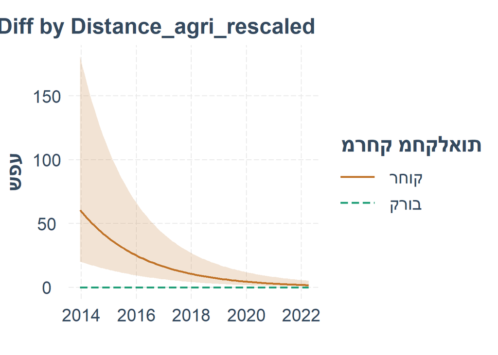

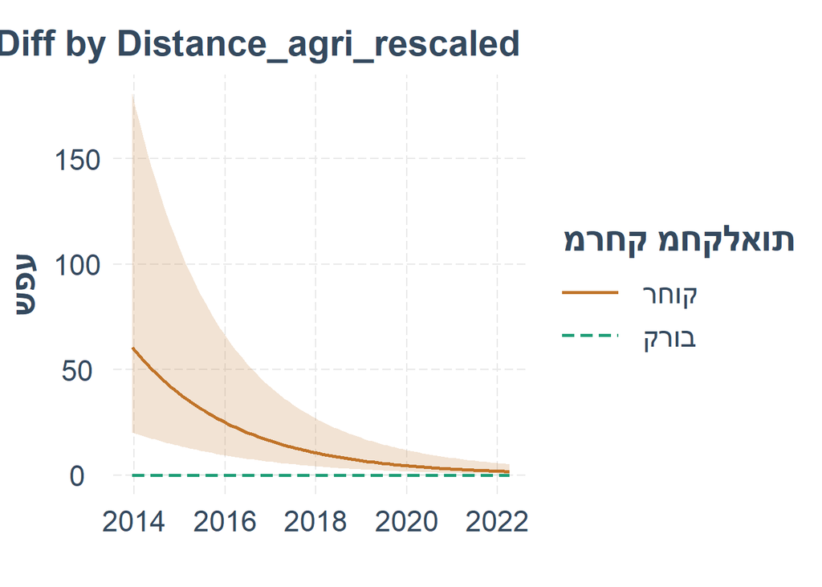

```r
source("../functions/plot_interaction_mammals.R")

plot_model_interaction(P.anal = Capra.nubiana.two.sites, m = glm.Capra.nubiana, eff2plot = "rescaled_Time.Diff", modvar2plot = "Distance_agri_rescaled", plot_points = FALSE, export_plot = TRUE, outpath = "../output/arid/", fontname = "Almoni ML v5 AAA")
```

```r
# capra_interact <- interact_plot(model = glm.Capra.nubiana, data=Capra.nubiana.two.sites, pred = rescaled_Time.Diff, modx = Distance_agri_rescaled, partial.residuals = F, modx.values = "plus-minus", jitter = c(0.2), point.size = 3, rug = F, point.shape = F, interval = T, colors = "Dark2") + scale_x_continuous(breaks=c(-1.233466888,-0.601840099,0.028922631,0.66054942,1.291312151), labels=c("June 2014", "June 2016", "June 2018", "June 2020", "June 2022"), name = "Time")


#Testing whether trends and means are different from zero

#Calculate mean and sd of distance from agriculture
sd_distance_agri <- sd(env_data$Distance_agri_rescaled)
print(sd_distance_agri)
```

```
## [1] 0.7725932
```

```r
mean_distance_agri <- mean(env_data$Distance_agri_rescaled)
print(mean_distance_agri)
```

```
## [1] 0.1973055
```

```r
#calculate +/1 1 SD
small_distance <- mean_distance_agri - sd_distance_agri
large_distance <- mean_distance_agri + sd_distance_agri

#Test whether temporal trend is different from zero
mm_rescaled_time <- emtrends(glm.Capra.nubiana, specs = "Distance_agri_rescaled", var = "rescaled_Time.Diff", type = "response", at = list(Distance_agri_rescaled = c(small_distance,large_distance)))
print(mm_rescaled_time)
```

```
##  Distance_agri_rescaled rescaled_Time.Diff.trend    SE  df asymp.LCL asymp.UCL
##                  -0.575                    0.929 0.723 Inf    -0.488     2.345
##                   0.970                   -1.049 0.187 Inf    -1.416    -0.683
##
## Results are averaged over the levels of: Site
## Confidence level used: 0.95
```

```r
test_results_mm_rescaled_time <- test(mm_rescaled_time, null = 0, adjust = "fdr")
print(test_results_mm_rescaled_time)
```

```
##  Distance_agri_rescaled rescaled_Time.Diff.trend    SE  df z.ratio p.value
##                  -0.575                    0.929 0.723 Inf   1.285  0.1988
##                   0.970                   -1.049 0.187 Inf  -5.609  <.0001
##
## Results are averaged over the levels of: Site
## P value adjustment: fdr method for 2 tests
```

```r
#Testing whether abundance is higher near or far from agriculture
pairwise_distance <- emmeans(object = glm.Capra.nubiana, ~Distance_agri_rescaled*rescaled_Time.Diff, at = list(Distance_agri_rescaled = c(small_distance,large_distance)))
print(pairwise_distance)
```

```
##  Distance_agri_rescaled rescaled_Time.Diff emmean    SE  df asymp.LCL asymp.UCL
##                  -0.575              0.281 -7.212 1.291 Inf     -9.74   -4.6812
##                   0.970              0.281 -0.642 0.355 Inf     -1.34    0.0541
##
## Results are averaged over the levels of: Site
## Results are given on the log (not the response) scale.
## Confidence level used: 0.95
```

```r
test_results_distance <- test(pairs(pairwise_distance, by="rescaled_Time.Diff"), by=NULL, adjust="fdr")
print(test_results_distance)
```

```
##  contrast
##  (Distance_agri_rescaled-0.575287691303192) - Distance_agri_rescaled0.96989861358702
##  rescaled_Time.Diff estimate   SE  df z.ratio p.value
##               0.281    -6.57 1.05 Inf  -6.255  <.0001
##
## Results are averaged over the levels of: Site
## Results are given on the log (not the response) scale.
```

```r
####Gazella dorcas####

Gazella.dorcas <- spp_no_rare[,"Gazella.dorcas"]
glm.Gazella.dorcas <- glm.nb(Gazella.dorcas ~ Distance_agri_rescaled * rescaled_Time.Diff + cosinus_Monitoring.Time.Diff + sinus_Monitoring.Time.Diff + Site, data = env_data, maxit = 999)
coef(glm.Gazella.dorcas)
```

```
##                               (Intercept)
##                                -3.7672758
##                    Distance_agri_rescaled
##                                 2.8142456
##                        rescaled_Time.Diff
##                                 0.9843487
##              cosinus_Monitoring.Time.Diff
##                                 0.7685811
##                sinus_Monitoring.Time.Diff
##                                -0.6974723
##                                 SiteLotan
##                                 3.0095339
##                                 SiteParan
##                                 3.5212432
##                                 SiteZofar
##                                 3.8563009
##                             SiteEin Yahav
##                                 2.5765897
## Distance_agri_rescaled:rescaled_Time.Diff
##                                -0.9174520
```

```r
coef(mva_m0.nb)
```

```
##                                           Canis.aureus  Canis.lupus
## (Intercept)                                 0.69252453 -1.267224310
## Distance_agri_rescaled                     -1.18759646  0.502207397
## rescaled_Time.Diff                          0.56347272  1.601455556
## cosinus_Monitoring.Time.Diff               -0.31595816  0.556084286
## sinus_Monitoring.Time.Diff                  0.06535263  0.908012936
## SiteLotan                                  -3.29327281 -1.100984348
## SiteParan                                  -5.11279350  0.095262226
## SiteZofar                                  -4.01381142 -1.688544946
## SiteEin Yahav                              -5.43535222 -1.260133169
## Distance_agri_rescaled:rescaled_Time.Diff  -0.83830144  0.004557944
##                                           Capra.nubiana Gazella.dorcas
## (Intercept)                                   -8.460181     -3.7674126
## Distance_agri_rescaled                         4.611579      2.8143264
## rescaled_Time.Diff                             0.192041      0.9843444
## cosinus_Monitoring.Time.Diff                   2.464587      0.7685791
## sinus_Monitoring.Time.Diff                     3.612071     -0.6974734
## SiteLotan                                      3.138868      3.0096643
## SiteParan                                     -8.705339      3.5213536
## SiteZofar                                     -6.446088      3.8564988
## SiteEin Yahav                                -11.167216      2.5766650
## Distance_agri_rescaled:rescaled_Time.Diff     -1.279655     -0.9174263
##                                           Hyaena.hyaena Lepus.capensis
## (Intercept)                                  -1.3226630    -1.47294721
## Distance_agri_rescaled                        0.2034286    -0.01452709
## rescaled_Time.Diff                           -0.1322795     0.46253783
## cosinus_Monitoring.Time.Diff                  0.3764462    -0.06510093
## sinus_Monitoring.Time.Diff                    0.1265160    -0.09094098
## SiteLotan                                    -0.4513221     0.47870879
## SiteParan                                    -0.2005448     1.04514367
## SiteZofar                                     0.6285472     2.04366525
## SiteEin Yahav                                -0.2965664     3.47451516
## Distance_agri_rescaled:rescaled_Time.Diff     0.1286649     0.27140401
##                                           Vulpes.vulpes
## (Intercept)                                   1.4261256
## Distance_agri_rescaled                       -0.8380766
## rescaled_Time.Diff                            0.1301859
## cosinus_Monitoring.Time.Diff                 -0.3238206
## sinus_Monitoring.Time.Diff                    0.2567386
## SiteLotan                                    -1.1567613
## SiteParan                                    -1.2343164
## SiteZofar                                    -3.2675189
## SiteEin Yahav                                -1.9164041
## Distance_agri_rescaled:rescaled_Time.Diff     0.2614349
```

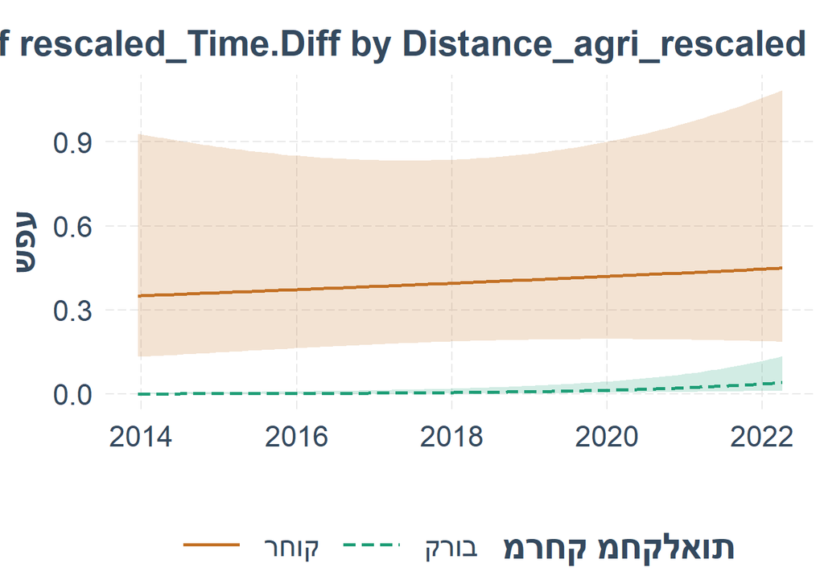

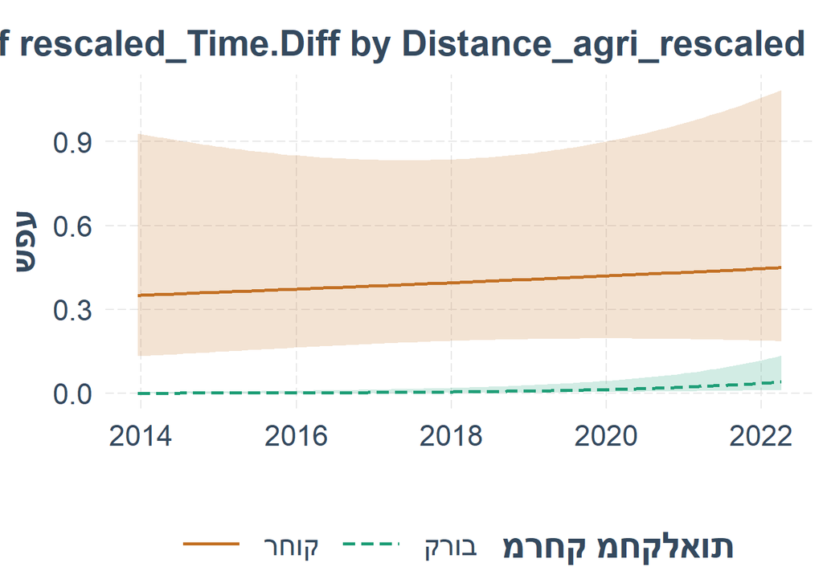

```r
plot_model_interaction(P.anal = env_data, m = glm.Gazella.dorcas, eff2plot = "rescaled_Time.Diff", modvar2plot = "Distance_agri_rescaled", plot_points = FALSE, export_plot = TRUE, outpath = "../output/arid/", fontname = "Almoni ML v5 AAA", legend_position = "bottom")
```

```r
# interact_plot(model = glm.Gazella.dorcas, data=env_data, pred = rescaled_Time.Diff, modx = Distance_agri_rescaled, partial.residuals = F, modx.values = "plus-minus", jitter = c(0.2), point.size = 3, rug = F, point.shape = F, interval = T, colors = "Dark2") + scale_x_continuous(breaks=c(-1.233466888,-0.601840099,0.028922631,0.66054942,1.291312151), labels=c("June 2014", "June 2016", "June 2018", "June 2020", "June 2022"), name = "Time")

#Test whether temporal trend is different from zero
mm_rescaled_time <- emtrends(glm.Gazella.dorcas, specs = "Distance_agri_rescaled", var = "rescaled_Time.Diff", type = "response", at = list(Distance_agri_rescaled = c(small_distance,large_distance)))
print(mm_rescaled_time)
```

```
##  Distance_agri_rescaled rescaled_Time.Diff.trend    SE  df asymp.LCL asymp.UCL
##                  -0.575                   1.5121 0.316 Inf     0.892     2.132
##                   0.970                   0.0945 0.214 Inf    -0.325     0.514
##
## Results are averaged over the levels of: Site
## Confidence level used: 0.95
```

```r
test_results_mm_rescaled_time <- test(mm_rescaled_time, null = 0, adjust = "fdr")
print(test_results_mm_rescaled_time)
```

```
##  Distance_agri_rescaled rescaled_Time.Diff.trend    SE  df z.ratio p.value
##                  -0.575                   1.5121 0.316 Inf   4.780  <.0001
##                   0.970                   0.0945 0.214 Inf   0.441  0.6591
##
## Results are averaged over the levels of: Site
## P value adjustment: fdr method for 2 tests
```

```r
#Testing whether abundance is higher near or far from agriculture
pairwise_distance <- emmeans(object = glm.Gazella.dorcas, ~Distance_agri_rescaled*rescaled_Time.Diff, at = list(Distance_agri_rescaled = c(small_distance,large_distance)))
print(pairwise_distance)
```

```
##  Distance_agri_rescaled rescaled_Time.Diff emmean    SE  df asymp.LCL asymp.UCL
##                  -0.575              0.277  -2.27 0.314 Inf     -2.88     -1.65
##                   0.970              0.277   1.69 0.172 Inf      1.35      2.03
##
## Results are averaged over the levels of: Site
## Results are given on the log (not the response) scale.
## Confidence level used: 0.95
```

```r
test_results_distance <- test(pairs(pairwise_distance, by="rescaled_Time.Diff"), by=NULL, adjust="fdr")
print(test_results_distance)
```

```
##  contrast
##  (Distance_agri_rescaled-0.575287691303192) - Distance_agri_rescaled0.96989861358702
##  rescaled_Time.Diff estimate    SE  df z.ratio p.value
##               0.277    -3.96 0.374 Inf -10.570  <.0001
##
## Results are averaged over the levels of: Site
## Results are given on the log (not the response) scale.
```

Capra:

Temporal trend is significantly different from zero in large distances from agriculture (p < 0.0001) and not significantly different from zero in small distances (p = 0.19)

Gazella dorcas:

Temporal trend is significantly different from zero in small distances from agriculture (p < 0.0001) and not significantly different from zero in large distances (p = 0.65)

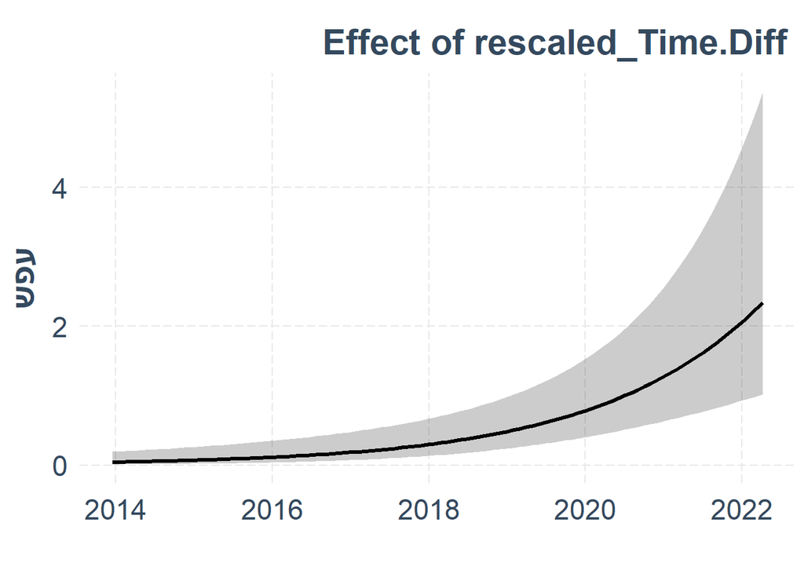

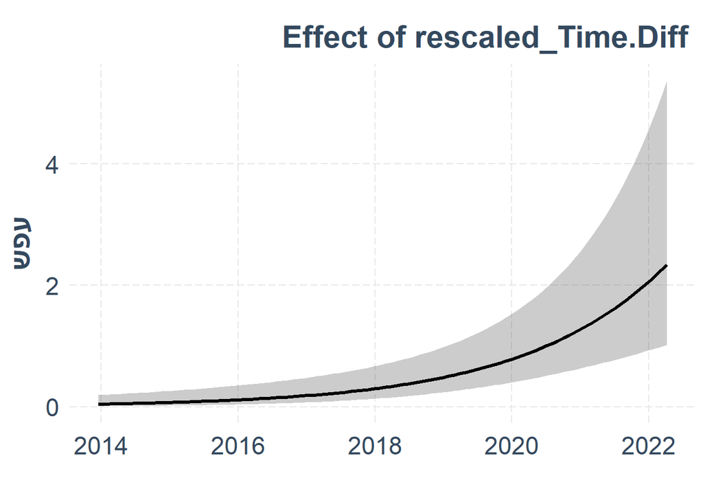

```r
####Canis aureus####

only_canis_aur_data <- P.anal[,c(1:27)]
Canis.aureus.only.yotvata <- only_canis_aur_data[Site %in% c("Yotvata")]
Canis.aureus <- spp_no_rare[,"Canis.aureus"]
glm.Canis.aureus <- glm.nb(`Canis aureus` ~ Distance_agri_rescaled + rescaled_Time.Diff + cosinus_Monitoring.Time.Diff + sinus_Monitoring.Time.Diff, data = Canis.aureus.only.yotvata, maxit = 999)
#coef(glm.Canis.aureus)
#coef(mva_m0.nb)

source("../functions/plot_model_effect_mammals.R")

plot_model_effect(P.anal = Canis.aureus.only.yotvata, m = glm.Canis.aureus, eff2plot = "rescaled_Time.Diff", plot_points=FALSE, plot_residuals=FALSE, export_plot=TRUE, ylabel = NULL, fontname = "Almoni ML v5 AAA", fontsize=22, pdf_width=160, outpath = "../output/arid/")
```

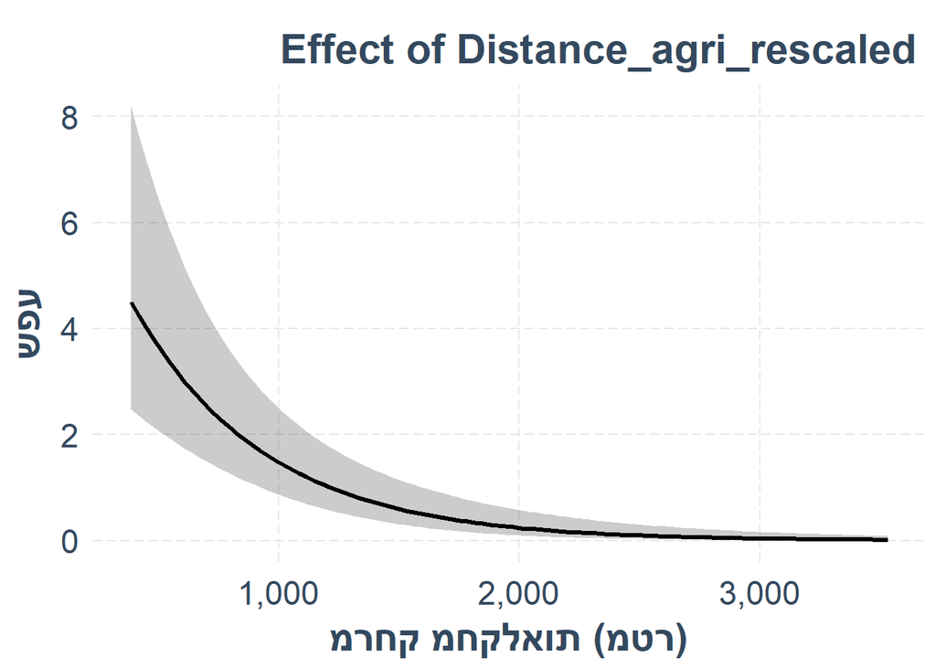

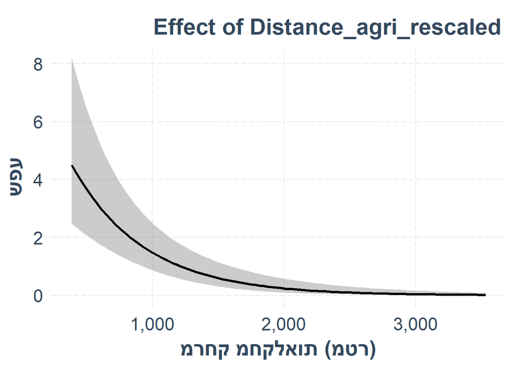

```r
# effect_plot(model = glm.Canis.aureus, data=Canis.aureus.only.yotvata, pred = rescaled_Time.Diff, interval = T, plot.points = F, jitter = c(0.1,0), point.size = 3, cat.pred.point.size = 4, partial.residuals = F, colors = "Qual1") + ylim(0,5) + scale_x_continuous(breaks=c(-1.233466888,-0.601840099,0.028922631,0.66054942,1.291312151), labels=c("June 2014", "June 2016", "June 2018", "June 2020", "June 2022"), name = "Time")

plot_model_effect(P.anal = Canis.aureus.only.yotvata, m = glm.Canis.aureus, eff2plot = "Distance_agri_rescaled", plot_points=FALSE, plot_residuals=FALSE, export_plot=TRUE, ylabel = NULL, fontname = "Almoni ML v5 AAA", fontsize=22, pdf_width=160, outpath = "../output/arid/")
```

```r
# effect_plot(model = glm.Canis.aureus, data=Canis.aureus.only.yotvata, pred = Distance_agri_rescaled, interval = T, plot.points = F, jitter = c(0.1,0), point.size = 3, cat.pred.point.size = 4, partial.residuals = F, colors = "Qual1") + scale_x_continuous(breaks=c(-0.589201946,0.245068396,1.172035444,2.099002491), labels=c("100", "1000", "2000", "3000"), name = "Distance (m)")
#

####Canis lupus####

Canis.lupus <- spp_no_rare[,"Canis.lupus"]
glm.Canis.lupus <- glm.nb(Canis.lupus ~ Distance_agri_rescaled + rescaled_Time.Diff + cosinus_Monitoring.Time.Diff + sinus_Monitoring.Time.Diff + Site, data = env_data, maxit = 999)
coef(glm.Canis.lupus)
```

```
##                  (Intercept)       Distance_agri_rescaled
##                  -1.26773275                   0.50367984
##           rescaled_Time.Diff cosinus_Monitoring.Time.Diff
##                   1.60219090                   0.55545107
##   sinus_Monitoring.Time.Diff                    SiteLotan
##                   0.90840035                  -1.10096642
##                    SiteParan                    SiteZofar
##                   0.09479091                  -1.68726381
##                SiteEin Yahav
##                  -1.26068664
```

```r
coef(mva_m0.nb)
```

```
##                                           Canis.aureus  Canis.lupus
## (Intercept)                                 0.69252453 -1.267224310
## Distance_agri_rescaled                     -1.18759646  0.502207397
## rescaled_Time.Diff                          0.56347272  1.601455556
## cosinus_Monitoring.Time.Diff               -0.31595816  0.556084286
## sinus_Monitoring.Time.Diff                  0.06535263  0.908012936
## SiteLotan                                  -3.29327281 -1.100984348
## SiteParan                                  -5.11279350  0.095262226
## SiteZofar                                  -4.01381142 -1.688544946
## SiteEin Yahav                              -5.43535222 -1.260133169
## Distance_agri_rescaled:rescaled_Time.Diff  -0.83830144  0.004557944
##                                           Capra.nubiana Gazella.dorcas
## (Intercept)                                   -8.460181     -3.7674126
## Distance_agri_rescaled                         4.611579      2.8143264
## rescaled_Time.Diff                             0.192041      0.9843444
## cosinus_Monitoring.Time.Diff                   2.464587      0.7685791
## sinus_Monitoring.Time.Diff                     3.612071     -0.6974734
## SiteLotan                                      3.138868      3.0096643
## SiteParan                                     -8.705339      3.5213536
## SiteZofar                                     -6.446088      3.8564988
## SiteEin Yahav                                -11.167216      2.5766650
## Distance_agri_rescaled:rescaled_Time.Diff     -1.279655     -0.9174263
##                                           Hyaena.hyaena Lepus.capensis
## (Intercept)                                  -1.3226630    -1.47294721
## Distance_agri_rescaled                        0.2034286    -0.01452709
## rescaled_Time.Diff                           -0.1322795     0.46253783
## cosinus_Monitoring.Time.Diff                  0.3764462    -0.06510093
## sinus_Monitoring.Time.Diff                    0.1265160    -0.09094098
## SiteLotan                                    -0.4513221     0.47870879
## SiteParan                                    -0.2005448     1.04514367
## SiteZofar                                     0.6285472     2.04366525
## SiteEin Yahav                                -0.2965664     3.47451516
## Distance_agri_rescaled:rescaled_Time.Diff     0.1286649     0.27140401
##                                           Vulpes.vulpes
## (Intercept)                                   1.4261256
## Distance_agri_rescaled                       -0.8380766
## rescaled_Time.Diff                            0.1301859
## cosinus_Monitoring.Time.Diff                 -0.3238206
## sinus_Monitoring.Time.Diff                    0.2567386
## SiteLotan                                    -1.1567613
## SiteParan                                    -1.2343164
## SiteZofar                                    -3.2675189
## SiteEin Yahav                                -1.9164041
## Distance_agri_rescaled:rescaled_Time.Diff     0.2614349
```

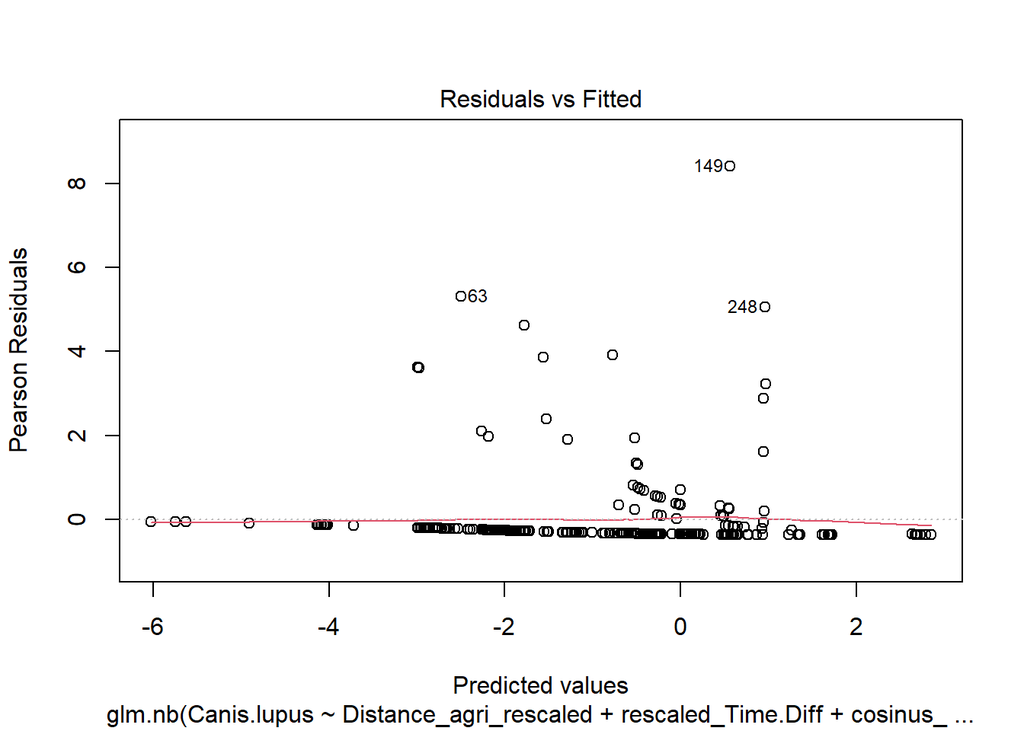

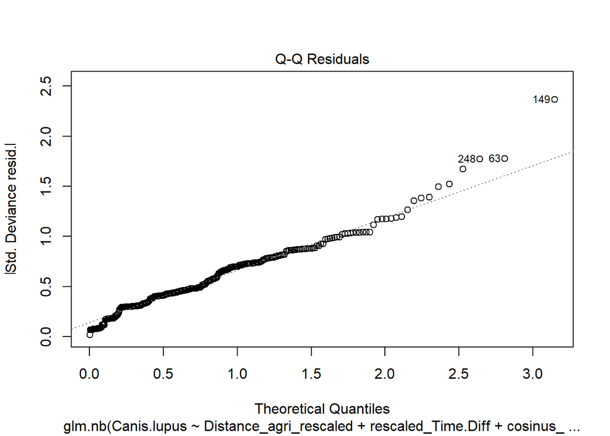

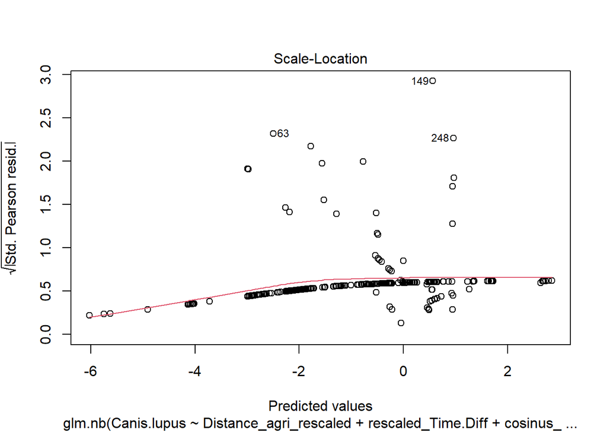

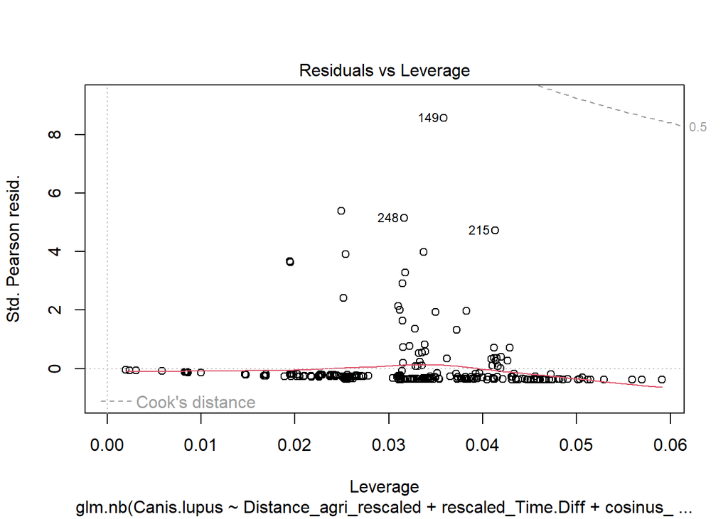

```r
plot(glm.Canis.lupus)
```

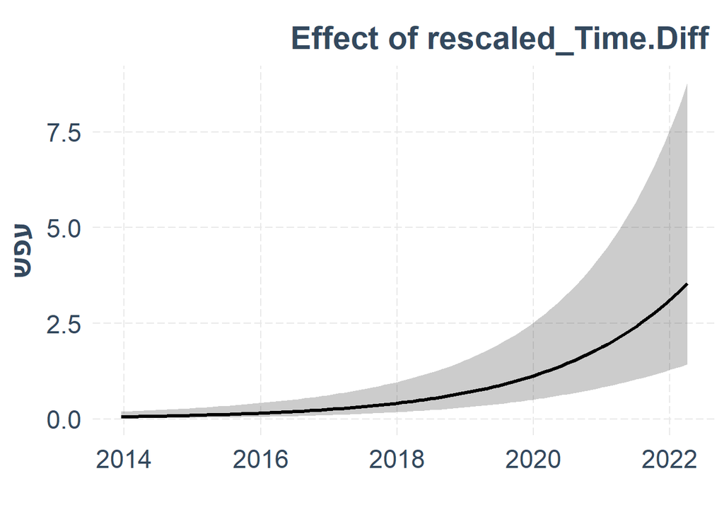

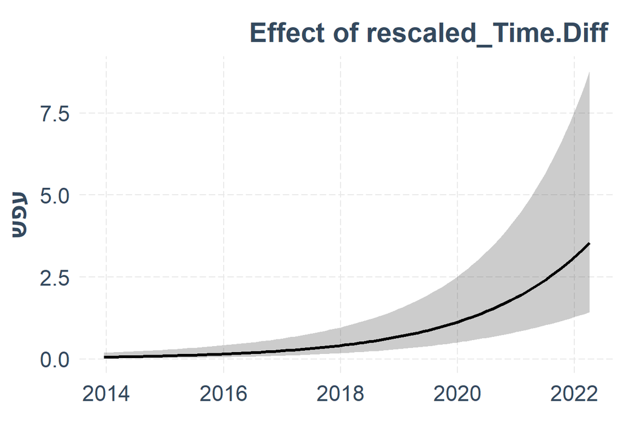

```r
plot_model_effect(P.anal = env_data, m = glm.Canis.lupus, eff2plot = "rescaled_Time.Diff", plot_points=FALSE, plot_residuals=FALSE, export_plot=TRUE, ylabel = NULL, fontname = "Almoni ML v5 AAA", fontsize=22, pdf_width=160, outpath = "../output/arid/")
```

```r
# effect_plot(model = glm.Canis.lupus, data=env_data, pred = rescaled_Time.Diff, interval = T, plot.points = F, jitter = c(0.1,0), point.size = 3, cat.pred.point.size = 4, partial.residuals = F, colors = "Qual1") + scale_x_continuous(breaks=c(-1.233466888,-0.601840099,0.028922631,0.66054942,1.291312151), labels=c("June 2014", "June 2016", "June 2018", "June 2020", "June 2022"), name = "Time")
```

n = 303 (total number of cameras)

total abundance = 3035 (10 species)

total abundance without rare species = 2933 (7 species)